# Data 607 Project 2

Monu Chacko

March 9, 2019

### The goal of this assignment is to give you practice in preparing different datasets for downstream analysis work.

#### Your task is to:

#### (1) Choose any three of the “wide” datasets identified in the Week 5 Discussion items. (You may use your own dataset; please don’t use my Sample Post dataset, since that was used in your Week 6 assignment!) For each of the three chosen datasets:

#### - Create a .CSV file (or optionally, a MySQL database!) that includes all of the information included in the dataset. You’re encouraged to use a “wide” structure similar to how the information appears in the discussion item, so that you can practice tidying and transformations as described below.

#### - Read the information from your .CSV file into R, and use tidyr and dplyr as needed to tidy and transform your data. [Most of your grade will be based on this step!]

#### - Perform the analysis requested in the discussion item.

#### - Your code should be in an R Markdown file, posted to rpubs.com, and should include narrative descriptions of your data cleanup work, analysis,and conclusions.

#### (2) Please include in your homework submission, for each of the three chosen datasets:

#### - The URLto the .Rmdfile in your GitHub repository,and

#### - The URL for your rpubs.com web page.

### DATASET 1: HEART

#### Source: https://www.kaggle.com/ronitf/heart-disease-uci

Attribute Information: 1. age 2. sex 3. chest pain type (4 values) 4. resting blood pressure 5. serum cholestoral in mg/dl 6. fasting blood sugar > 120 mg/dl 7. resting electrocardiographic results (values 0,1,2) 8. maximum heart rate achieved 9. exercise induced angina 10. oldpeak = ST depression induced by exercise relative to rest 11. the slope of the peak exercise ST segment 12. number of major vessels (0-3) colored by flourosopy 13. thal: 3 = normal; 6 = fixed defect; 7 = reversable defect

```r
#Load all required packages
library(DT)
library(tidyr)
library(dplyr)
library(ggplot2)

#Read data from csv
heart_ds <- read.csv(file="Heart.csv", header=TRUE, sep=",")

#View sample data
head(heart_ds)
```

```
##   ï..age sex cp trestbps chol fbs restecg thalach exang oldpeak slope ca
## 1     63   1  3      145  233   1       0     150     0     2.3     0  0
## 2     37   1  2      130  250   0       1     187     0     3.5     0  0
## 3     41   0  1      130  204   0       0     172     0     1.4     2  0
## 4     56   1  1      120  236   0       1     178     0     0.8     2  0
## 5     57   0  0      120  354   0       1     163     1     0.6     2  0
## 6     57   1  0      140  192   0       1     148     0     0.4     1  0
##   thal target
## 1    1      1
## 2    2      1
## 3    2      1
## 4    2      1
## 5    2      1
## 6    1      1
```

```r
#Examine the current columns
colnames(heart_ds)
```

```
##  [1] "ï..age"   "sex"      "cp"       "trestbps" "chol"     "fbs"
##  [7] "restecg"  "thalach"  "exang"    "oldpeak"  "slope"    "ca"
## [13] "thal"     "target"
```

```r
#Rename columns
colnames(heart_ds) <- c("age","sex","chest_pain","bp","chol","sugar","cardio","hrt_rt","exer",  "oldpeak","slope","ca","thal","target")

str(heart_ds)
```

```
## 'data.frame':    303 obs. of  14 variables:
##  $ age       : int  63 37 41 56 57 57 56 44 52 57 ...
##  $ sex       : int  1 1 0 1 0 1 0 1 1 1 ...
##  $ chest_pain: int  3 2 1 1 0 0 1 1 2 2 ...
##  $ bp        : int  145 130 130 120 120 140 140 120 172 150 ...
##  $ chol      : int  233 250 204 236 354 192 294 263 199 168 ...
##  $ sugar     : int  1 0 0 0 0 0 0 0 1 0 ...
##  $ cardio    : int  0 1 0 1 1 1 0 1 1 1 ...
##  $ hrt_rt    : int  150 187 172 178 163 148 153 173 162 174 ...
##  $ exer      : int  0 0 0 0 1 0 0 0 0 0 ...
##  $ oldpeak   : num  2.3 3.5 1.4 0.8 0.6 0.4 1.3 0 0.5 1.6 ...
##  $ slope     : int  0 0 2 2 2 1 1 2 2 2 ...
##  $ ca        : int  0 0 0 0 0 0 0 0 0 0 ...
##  $ thal      : int  1 2 2 2 2 1 2 3 3 2 ...
##  $ target    : int  1 1 1 1 1 1 1 1 1 1 ...
```

```r
#Summary
summary(heart_ds)
```

```
##       age             sex           chest_pain          bp
##  Min.   :29.00   Min.   :0.0000   Min.   :0.000   Min.   : 94.0
##  1st Qu.:47.50   1st Qu.:0.0000   1st Qu.:0.000   1st Qu.:120.0
##  Median :55.00   Median :1.0000   Median :1.000   Median :130.0
##  Mean   :54.37   Mean   :0.6832   Mean   :0.967   Mean   :131.6
##  3rd Qu.:61.00   3rd Qu.:1.0000   3rd Qu.:2.000   3rd Qu.:140.0
##  Max.   :77.00   Max.   :1.0000   Max.   :3.000   Max.   :200.0
##       chol           sugar            cardio           hrt_rt
##  Min.   :126.0   Min.   :0.0000   Min.   :0.0000   Min.   : 71.0
##  1st Qu.:211.0   1st Qu.:0.0000   1st Qu.:0.0000   1st Qu.:133.5
##  Median :240.0   Median :0.0000   Median :1.0000   Median :153.0
##  Mean   :246.3   Mean   :0.1485   Mean   :0.5281   Mean   :149.6
##  3rd Qu.:274.5   3rd Qu.:0.0000   3rd Qu.:1.0000   3rd Qu.:166.0
##  Max.   :564.0   Max.   :1.0000   Max.   :2.0000   Max.   :202.0
##       exer           oldpeak         slope             ca
##  Min.   :0.0000   Min.   :0.00   Min.   :0.000   Min.   :0.0000
##  1st Qu.:0.0000   1st Qu.:0.00   1st Qu.:1.000   1st Qu.:0.0000
##  Median :0.0000   Median :0.80   Median :1.000   Median :0.0000
##  Mean   :0.3267   Mean   :1.04   Mean   :1.399   Mean   :0.7294
##  3rd Qu.:1.0000   3rd Qu.:1.60   3rd Qu.:2.000   3rd Qu.:1.0000
##  Max.   :1.0000   Max.   :6.20   Max.   :2.000   Max.   :4.0000
##       thal           target
##  Min.   :0.000   Min.   :0.0000
##  1st Qu.:2.000   1st Qu.:0.0000
##  Median :2.000   Median :1.0000
##  Mean   :2.314   Mean   :0.5446
##  3rd Qu.:3.000   3rd Qu.:1.0000
##  Max.   :3.000   Max.   :1.0000
```

```r
#View data
datatable(heart_ds)
```

|  | age | sex | chest_pain | bp | chol | sugar | cardio | hrt_rt | exer | oldpeak | slope | ca | thal | target |
| --- | --- | --- | --- | --- | --- | --- | --- | --- | --- | --- | --- | --- | --- | --- |
| 1 | 63 | 1 | 3 | 145 | 233 | 1 | 0 | 150 | 0 | 2.3 | 0 | 0 | 1 | 1 |
| 2 | 37 | 1 | 2 | 130 | 250 | 0 | 1 | 187 | 0 | 3.5 | 0 | 0 | 2 | 1 |
| 3 | 41 | 0 | 1 | 130 | 204 | 0 | 0 | 172 | 0 | 1.4 | 2 | 0 | 2 | 1 |
| 4 | 56 | 1 | 1 | 120 | 236 | 0 | 1 | 178 | 0 | 0.8 | 2 | 0 | 2 | 1 |
| 5 | 57 | 0 | 0 | 120 | 354 | 0 | 1 | 163 | 1 | 0.6 | 2 | 0 | 2 | 1 |
| 6 | 57 | 1 | 0 | 140 | 192 | 0 | 1 | 148 | 0 | 0.4 | 1 | 0 | 1 | 1 |
| 7 | 56 | 0 | 1 | 140 | 294 | 0 | 0 | 153 | 0 | 1.3 | 1 | 0 | 2 | 1 |
| 8 | 44 | 1 | 1 | 120 | 263 | 0 | 1 | 173 | 0 | 0 | 2 | 0 | 3 | 1 |
| 9 | 52 | 1 | 2 | 172 | 199 | 1 | 1 | 162 | 0 | 0.5 | 2 | 0 | 3 | 1 |
| 10 | 57 | 1 | 2 | 150 | 168 | 0 | 1 | 174 | 0 | 1.6 | 2 | 0 | 2 | 1 |

[output cut: 293 more lines]

```r
#Remove unwanted data
new_cols <- c("age","sex","chest_pain","bp","chol","sugar","cardio","hrt_rt")
heart_ds_new <- heart_ds[new_cols]

#View new data
datatable(heart_ds_new)
```

|  | age | sex | chest_pain | bp | chol | sugar | cardio | hrt_rt |
| --- | --- | --- | --- | --- | --- | --- | --- | --- |
| 1 | 63 | 1 | 3 | 145 | 233 | 1 | 0 | 150 |
| 2 | 37 | 1 | 2 | 130 | 250 | 0 | 1 | 187 |
| 3 | 41 | 0 | 1 | 130 | 204 | 0 | 0 | 172 |
| 4 | 56 | 1 | 1 | 120 | 236 | 0 | 1 | 178 |
| 5 | 57 | 0 | 0 | 120 | 354 | 0 | 1 | 163 |
| 6 | 57 | 1 | 0 | 140 | 192 | 0 | 1 | 148 |
| 7 | 56 | 0 | 1 | 140 | 294 | 0 | 0 | 153 |
| 8 | 44 | 1 | 1 | 120 | 263 | 0 | 1 | 173 |
| 9 | 52 | 1 | 2 | 172 | 199 | 1 | 1 | 162 |
| 10 | 57 | 1 | 2 | 150 | 168 | 0 | 1 | 174 |

[output cut: 293 more lines]

```r
#How many rows and columns
dim(heart_ds_new)
```

```
## [1] 303   8
```

```r
#Create two new category for sex.
heart_ds_new <- heart_ds_new %>% mutate(M=if_else(sex==1, 1, 0))
heart_ds_new <- heart_ds_new %>% mutate(F=if_else(sex==0, 1, 0))

#Put bp in categories
heart_ds_new <- heart_ds_new %>% mutate(bp_cat=if_else(bp>=120, "high",
                                                         if_else(bp<120, "Normal", "")))

#Create a feature for chest pain
heart_ds_new <- heart_ds_new %>% mutate(has_chest_pain=if_else(chest_pain>2, 1, 0))


heart_ds_new <- gather(data=heart_ds_new, key=sex_col, value=sex_count, M, F)
datatable(heart_ds_new)
```

|  | age | sex | chest_pain | bp | chol | sugar | cardio | hrt_rt | bp_cat | has_chest_pain | sex_col | sex_count |
| --- | --- | --- | --- | --- | --- | --- | --- | --- | --- | --- | --- | --- |
| 1 | 63 | 1 | 3 | 145 | 233 | 1 | 0 | 150 | high | 1 | M | 1 |
| 2 | 37 | 1 | 2 | 130 | 250 | 0 | 1 | 187 | high | 0 | M | 1 |
| 3 | 41 | 0 | 1 | 130 | 204 | 0 | 0 | 172 | high | 0 | M | 0 |
| 4 | 56 | 1 | 1 | 120 | 236 | 0 | 1 | 178 | high | 0 | M | 1 |
| 5 | 57 | 0 | 0 | 120 | 354 | 0 | 1 | 163 | high | 0 | M | 0 |
| 6 | 57 | 1 | 0 | 140 | 192 | 0 | 1 | 148 | high | 0 | M | 1 |
| 7 | 56 | 0 | 1 | 140 | 294 | 0 | 0 | 153 | high | 0 | M | 0 |
| 8 | 44 | 1 | 1 | 120 | 263 | 0 | 1 | 173 | high | 0 | M | 1 |
| 9 | 52 | 1 | 2 | 172 | 199 | 1 | 1 | 162 | high | 0 | M | 1 |
| 10 | 57 | 1 | 2 | 150 | 168 | 0 | 1 | 174 | high | 0 | M | 1 |

[output cut: 596 more lines]

#### Analysis

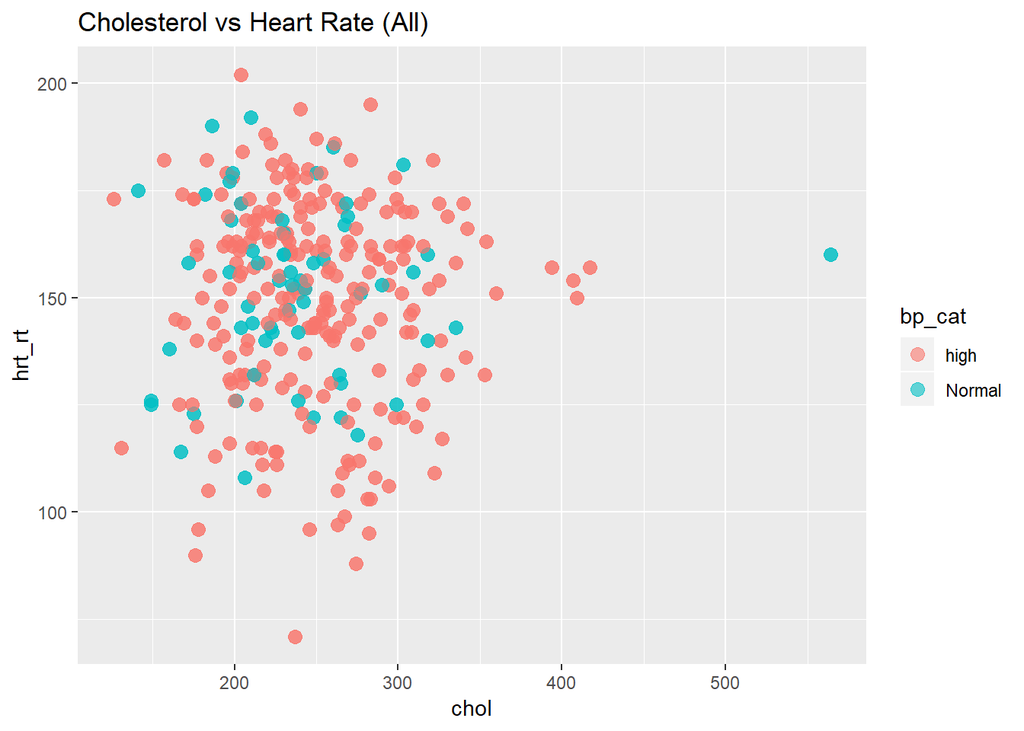

```r
#Examine data for the entire population,
qplot(data=heart_ds_new, x=chol, y=hrt_rt, size=I(3), color=bp_cat, alpha=I(0.6), main="Cholesterol vs Heart Rate (All)")
```

#### Cholesterol vs heart Rate doesn’t seems to have any significant relation. We could drop this from analysis and explore more.

#### For population above 60

```r
#Lets look at population above 60
heart_ds_new_above60 <- filter(heart_ds_new, age > 60)

#60 and male
heart_ds_new_above60_m <- filter(heart_ds_new_above60, age > 60 & sex==1)

#60 and female
heart_ds_new_above60_f <- filter(heart_ds_new_above60, age > 60 & sex==1)

#Convert bp to percent
heart_ds_new_above60 <- mutate(heart_ds_new_above60, bp_pr = (bp/100))

#View above 60 data
datatable(heart_ds_new_above60)
```

|  | age | sex | chest_pain | bp | chol | sugar | cardio | hrt_rt | bp_cat | has_chest_pain | sex_col | sex_count | bp_pr |
| --- | --- | --- | --- | --- | --- | --- | --- | --- | --- | --- | --- | --- | --- |
| 1 | 63 | 1 | 3 | 145 | 233 | 1 | 0 | 150 | high | 1 | M | 1 | 1.45 |
| 2 | 64 | 1 | 3 | 110 | 211 | 0 | 0 | 144 | Normal | 1 | M | 1 | 1.1 |
| 3 | 66 | 0 | 3 | 150 | 226 | 0 | 1 | 114 | high | 1 | M | 0 | 1.5 |
| 4 | 69 | 0 | 3 | 140 | 239 | 0 | 1 | 151 | high | 1 | M | 0 | 1.4 |
| 5 | 61 | 1 | 2 | 150 | 243 | 1 | 1 | 137 | high | 0 | M | 1 | 1.5 |
| 6 | 71 | 0 | 1 | 160 | 302 | 0 | 1 | 162 | high | 0 | M | 0 | 1.6 |
| 7 | 65 | 0 | 2 | 140 | 417 | 1 | 0 | 157 | high | 0 | M | 0 | 1.4 |
| 8 | 65 | 1 | 0 | 120 | 177 | 0 | 1 | 140 | high | 0 | M | 1 | 1.2 |
| 9 | 65 | 0 | 2 | 155 | 269 | 0 | 1 | 148 | high | 0 | M | 0 | 1.55 |
| 10 | 65 | 0 | 2 | 160 | 360 | 0 | 0 | 151 | high | 0 | M | 0 | 1.6 |

[output cut: 148 more lines]

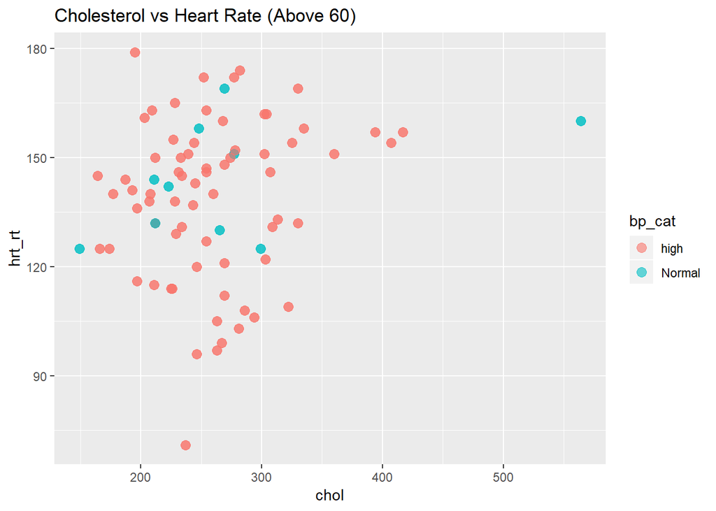

```r
#Examine data for the entire population,
qplot(data=heart_ds_new_above60, x=chol, y=hrt_rt, size=I(3), color=bp_cat, alpha=I(0.6), main="Cholesterol vs Heart Rate (Above 60)")
```

#### For population below 60

```r
#Lets look at population below 60
heart_ds_new_below60 <- filter(heart_ds_new, age <= 60)

#Less than 60 and male
heart_ds_new_below60_m <- filter(heart_ds_new_below60, age <= 60 & sex==1)

#Less than 60 and female
heart_ds_new_above60_f <- filter(heart_ds_new_below60, age <= 60 & sex==1)

#Convert bp to percent
heart_ds_new_below60 <- mutate(heart_ds_new_below60, bp_pr = (bp/100))

#View above 60 data
datatable(heart_ds_new_below60)
```

|  | age | sex | chest_pain | bp | chol | sugar | cardio | hrt_rt | bp_cat | has_chest_pain | sex_col | sex_count | bp_pr |
| --- | --- | --- | --- | --- | --- | --- | --- | --- | --- | --- | --- | --- | --- |
| 1 | 37 | 1 | 2 | 130 | 250 | 0 | 1 | 187 | high | 0 | M | 1 | 1.3 |
| 2 | 41 | 0 | 1 | 130 | 204 | 0 | 0 | 172 | high | 0 | M | 0 | 1.3 |
| 3 | 56 | 1 | 1 | 120 | 236 | 0 | 1 | 178 | high | 0 | M | 1 | 1.2 |
| 4 | 57 | 0 | 0 | 120 | 354 | 0 | 1 | 163 | high | 0 | M | 0 | 1.2 |
| 5 | 57 | 1 | 0 | 140 | 192 | 0 | 1 | 148 | high | 0 | M | 1 | 1.4 |
| 6 | 56 | 0 | 1 | 140 | 294 | 0 | 0 | 153 | high | 0 | M | 0 | 1.4 |
| 7 | 44 | 1 | 1 | 120 | 263 | 0 | 1 | 173 | high | 0 | M | 1 | 1.2 |
| 8 | 52 | 1 | 2 | 172 | 199 | 1 | 1 | 162 | high | 0 | M | 1 | 1.72 |
| 9 | 57 | 1 | 2 | 150 | 168 | 0 | 1 | 174 | high | 0 | M | 1 | 1.5 |
| 10 | 54 | 1 | 0 | 140 | 239 | 0 | 1 | 160 | high | 0 | M | 1 | 1.4 |

[output cut: 438 more lines]

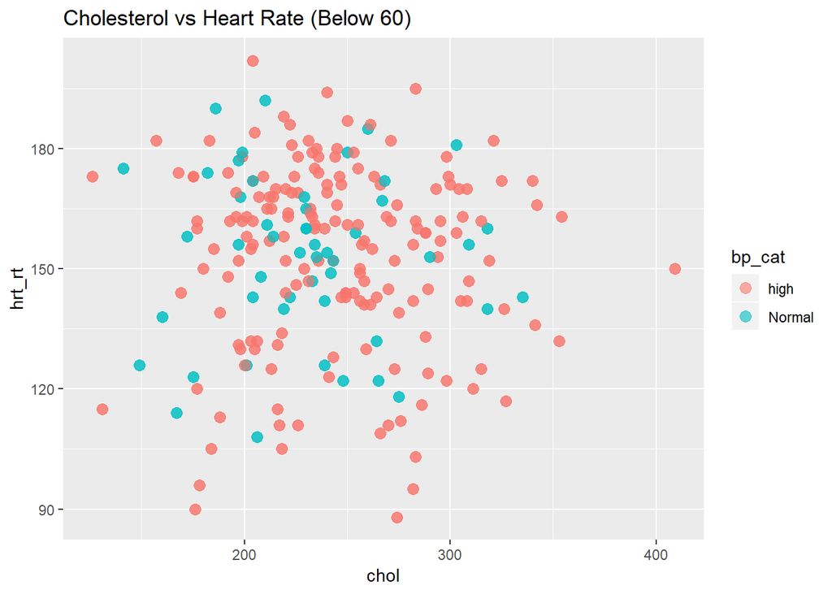

```r
#Examine data for the entire population,
qplot(data=heart_ds_new_below60, x=chol, y=hrt_rt, size=I(3), color=bp_cat, alpha=I(0.6), main="Cholesterol vs Heart Rate (Below 60)")
```

#### Examine age and cholesterol

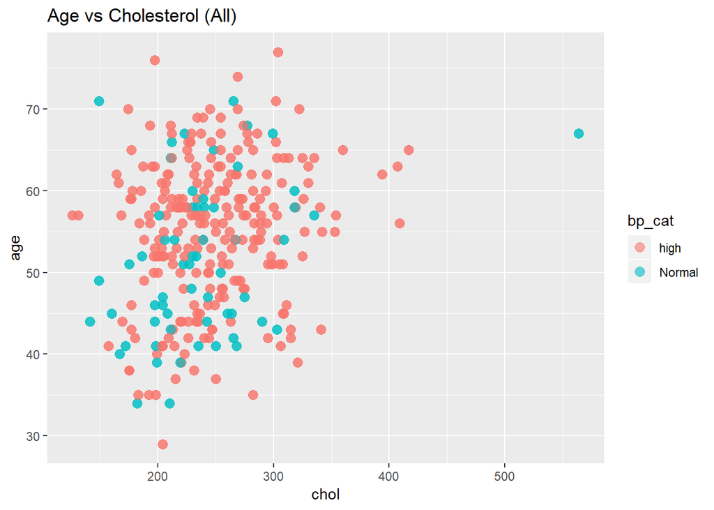

```r
#Age and cholesterol
qplot(data=heart_ds_new, x=chol, y=age, size=I(3), color=bp_cat, alpha=I(0.6), main="Age vs Cholesterol (All)")
```

### Conclusion

```r
#Look at the mean bp
summarise(heart_ds_new, mean(bp, na.rm=TRUE))
```

```
##   mean(bp, na.rm = TRUE)
## 1               131.6238
```

```r
#What about sex and bp
summarise(group_by(heart_ds_new, sex), mean(bp, na.rm=TRUE))
```

```
## # A tibble: 2 x 2
##     sex `mean(bp, na.rm = TRUE)`
##   <int>                    <dbl>
## 1     0                     133.
## 2     1                     131.
```

```r
#View random sample
datatable(sample_n(heart_ds_new, size=20))
```

|  | age | sex | chest_pain | bp | chol | sugar | cardio | hrt_rt | bp_cat | has_chest_pain | sex_col | sex_count |
| --- | --- | --- | --- | --- | --- | --- | --- | --- | --- | --- | --- | --- |
| 328 | 40 | 1 | 3 | 140 | 199 | 0 | 1 | 178 | high | 1 | F | 0 |
| 520 | 62 | 0 | 2 | 130 | 263 | 0 | 1 | 97 | high | 0 | F | 1 |
| 89 | 54 | 0 | 2 | 110 | 214 | 0 | 1 | 158 | Normal | 0 | M | 0 |
| 321 | 66 | 0 | 3 | 150 | 226 | 0 | 1 | 114 | high | 1 | F | 1 |
| 212 | 61 | 1 | 0 | 120 | 260 | 0 | 1 | 140 | high | 0 | M | 1 |
| 457 | 66 | 0 | 2 | 146 | 278 | 0 | 0 | 152 | high | 0 | F | 1 |
| 385 | 45 | 1 | 1 | 128 | 308 | 0 | 0 | 170 | high | 0 | F | 0 |
| 14 | 64 | 1 | 3 | 110 | 211 | 0 | 0 | 144 | Normal | 1 | M | 1 |
| 535 | 57 | 1 | 0 | 165 | 289 | 1 | 0 | 124 | high | 0 | F | 0 |
| 364 | 71 | 0 | 2 | 110 | 265 | 1 | 0 | 130 | Normal | 0 | F | 1 |

[output cut: 10 more lines]

```r
#View 10% of the data
datatable(sample_frac(heart_ds_new, size=.1))
```

|  | age | sex | chest_pain | bp | chol | sugar | cardio | hrt_rt | bp_cat | has_chest_pain | sex_col | sex_count |
| --- | --- | --- | --- | --- | --- | --- | --- | --- | --- | --- | --- | --- |
| 583 | 61 | 1 | 0 | 138 | 166 | 0 | 0 | 125 | high | 0 | F | 0 |
| 255 | 59 | 1 | 3 | 160 | 273 | 0 | 0 | 125 | high | 1 | M | 1 |
| 588 | 61 | 1 | 0 | 140 | 207 | 0 | 0 | 138 | high | 0 | F | 0 |
| 349 | 52 | 1 | 1 | 120 | 325 | 0 | 1 | 172 | high | 0 | F | 0 |
| 33 | 44 | 1 | 1 | 130 | 219 | 0 | 0 | 188 | high | 0 | M | 1 |
| 83 | 60 | 0 | 2 | 102 | 318 | 0 | 1 | 160 | Normal | 0 | M | 0 |
| 447 | 67 | 0 | 0 | 106 | 223 | 0 | 1 | 142 | Normal | 0 | F | 1 |
| 410 | 69 | 1 | 3 | 160 | 234 | 1 | 0 | 131 | high | 1 | F | 0 |
| 171 | 56 | 1 | 2 | 130 | 256 | 1 | 0 | 142 | high | 0 | M | 1 |
| 454 | 66 | 1 | 0 | 160 | 228 | 0 | 0 | 138 | high | 0 | F | 0 |

[output cut: 51 more lines]

```r
#How many male and female. Looks like we have uneven distribution.
count(heart_ds_new, sex)
```

```
## # A tibble: 2 x 2
##     sex     n
##   <int> <int>
## 1     0   192
## 2     1   414
```

```r
#sort
datatable(arrange(heart_ds_new, desc(age), sex))
```

|  | age | sex | chest_pain | bp | chol | sugar | cardio | hrt_rt | bp_cat | has_chest_pain | sex_col | sex_count |
| --- | --- | --- | --- | --- | --- | --- | --- | --- | --- | --- | --- | --- |
| 1 | 77 | 1 | 0 | 125 | 304 | 0 | 0 | 162 | high | 0 | M | 1 |
| 2 | 77 | 1 | 0 | 125 | 304 | 0 | 0 | 162 | high | 0 | F | 0 |
| 3 | 76 | 0 | 2 | 140 | 197 | 0 | 2 | 116 | high | 0 | M | 0 |
| 4 | 76 | 0 | 2 | 140 | 197 | 0 | 2 | 116 | high | 0 | F | 1 |
| 5 | 74 | 0 | 1 | 120 | 269 | 0 | 0 | 121 | high | 0 | M | 0 |
| 6 | 74 | 0 | 1 | 120 | 269 | 0 | 0 | 121 | high | 0 | F | 1 |
| 7 | 71 | 0 | 1 | 160 | 302 | 0 | 1 | 162 | high | 0 | M | 0 |
| 8 | 71 | 0 | 2 | 110 | 265 | 1 | 0 | 130 | Normal | 0 | M | 0 |
| 9 | 71 | 0 | 0 | 112 | 149 | 0 | 1 | 125 | Normal | 0 | M | 0 |
| 10 | 71 | 0 | 1 | 160 | 302 | 0 | 1 | 162 | high | 0 | F | 1 |

[output cut: 596 more lines]

```r
#pipe operator for multiple func
heart_ds_new %>%
  filter(sex==1) %>%
  group_by(age) %>%
  summary(mean(age, na.rm=TRUE))
```

```
##       age             sex      chest_pain           bp
##  Min.   :29.00   Min.   :1   Min.   :0.0000   Min.   : 94.0
##  1st Qu.:47.00   1st Qu.:1   1st Qu.:0.0000   1st Qu.:120.0
##  Median :54.00   Median :1   Median :0.0000   Median :130.0
##  Mean   :53.76   Mean   :1   Mean   :0.9324   Mean   :130.9
##  3rd Qu.:59.75   3rd Qu.:1   3rd Qu.:2.0000   3rd Qu.:140.0
##  Max.   :77.00   Max.   :1   Max.   :3.0000   Max.   :192.0
##       chol           sugar            cardio           hrt_rt
##  Min.   :126.0   Min.   :0.0000   Min.   :0.0000   Min.   : 71
##  1st Qu.:208.0   1st Qu.:0.0000   1st Qu.:0.0000   1st Qu.:132
##  Median :235.0   Median :0.0000   Median :1.0000   Median :151
##  Mean   :239.3   Mean   :0.1594   Mean   :0.5072   Mean   :149
##  3rd Qu.:268.5   3rd Qu.:0.0000   3rd Qu.:1.0000   3rd Qu.:168
##  Max.   :353.0   Max.   :1.0000   Max.   :2.0000   Max.   :202
##     bp_cat          has_chest_pain      sex_col            sex_count
##  Length:414         Min.   :0.00000   Length:414         Min.   :0.0
##  Class :character   1st Qu.:0.00000   Class :character   1st Qu.:0.0
##  Mode  :character   Median :0.00000   Mode  :character   Median :0.5
##                     Mean   :0.09179                      Mean   :0.5
##                     3rd Qu.:0.00000                      3rd Qu.:1.0
##                     Max.   :1.00000                      Max.   :1.0
```

### DATASET 2: POPULATION vs MARRIAGE

#### Source: https://rawgit.com/nschettini/CUNY-MSDS-DATA-607/master/national_marriage_divorce_rates_00-16.csv

```r
library(tidyverse)

#Read data from csv
md_ds <- read.csv(file="national_marriage_divorce_rates_00-16.csv", header=FALSE, sep=",")

#View initial data
as.tibble(md_ds)
```

```
## # A tibble: 61 x 10
##    V1             V2     V3    V4       V5    V6    V7    V8    V9    V10
##    <fct>          <fct>  <fct> <fct>    <lgl> <lgl> <lgl> <lgl> <lgl> <lgl>
##  1 ï»¿Provisiona~ ""     ""    ""       NA    NA    NA    NA    NA    NA
##  2 ""             ""     ""    ""       NA    NA    NA    NA    NA    NA
##  3 Year           Marri~ Popu~ Rate pe~ NA    NA    NA    NA    NA    NA
##  4 2016           2,245~ 323,~ 6.9      NA    NA    NA    NA    NA    NA
##  5 2015           2,221~ 321,~ 6.9      NA    NA    NA    NA    NA    NA
##  6 2014/1         2,140~ 308,~ 6.9      NA    NA    NA    NA    NA    NA
##  7 2013/1         2,081~ 306,~ 6.8      NA    NA    NA    NA    NA    NA
##  8 2012           2,131~ 313,~ 6.8      NA    NA    NA    NA    NA    NA
##  9 2011           2,118~ 311,~ 6.8      NA    NA    NA    NA    NA    NA
## 10 2010           2,096~ 308,~ 6.8      NA    NA    NA    NA    NA    NA
## # ... with 51 more rows
```

```r
#md_ds_tb <- as.tibble(md_ds)
colnames(md_ds)
```

```
##  [1] "V1"  "V2"  "V3"  "V4"  "V5"  "V6"  "V7"  "V8"  "V9"  "V10"
```

```r
colnames(md_ds) <- c("years","marriage","population","population_rate","X.3","X.4","X.5","X.6","X.7","X.8")

#md_ds
md_ds <- md_ds[-c(33:61),]
md_ds <- md_ds[-c(21:32),]
md_ds <- md_ds[-c(1:3),]

#Remove unwanted data
md_ds_cols <- c("years","marriage","population","population_rate")
md_ds_new <- md_ds[md_ds_cols]

md_ds_new$years <- gsub("/\\d", "", md_ds_new$years)

#Reset the index
rownames(md_ds_new) <- 1:nrow(md_ds_new)


md_ds_new
```

```
##    years  marriage  population population_rate
## 1   2016 2,245,404 323,127,513             6.9
## 2   2015 2,221,579 321,418,820             6.9
## 3   2014 2,140,272 308,759,713             6.9
## 4   2013 2,081,301 306,136,672             6.8
## 5   2012 2,131,000 313,914,040             6.8
## 6   2011 2,118,000 311,591,917             6.8
## 7   2010 2,096,000 308,745,538             6.8
## 8   2009 2,080,000 306,771,529             6.8
## 9   2008 2,157,000 304,093,966             7.1
## 10  2007 2,197,000 301,231,207             7.3
## 11  2006 2,193,000 294,077,247             7.5
## 12  2005 2,249,000 295,516,599             7.6
## 13  2004 2,279,000 292,805,298             7.8
## 14  2003 2,245,000 290,107,933             7.7
## 15  2002 2,290,000 287,625,193             8.0
## 16  2001 2,326,000 284,968,955             8.2
## 17  2000 2,315,000 281,421,906             8.2
```

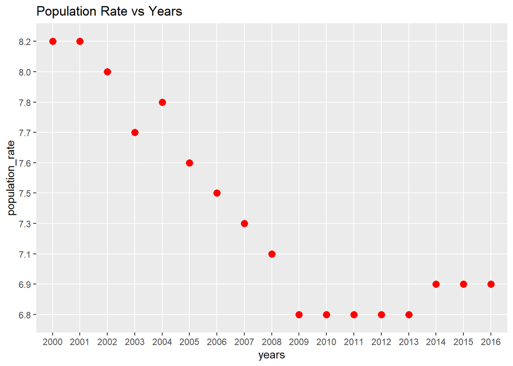

```r
#qplot(data=md_ds_new, x=population_rate, main="Population Rate")
#qplot(data=md_ds_new, x=marriage, y=population, size=I(3), color=I("Blue"), main="Marriage vs Population")
#qplot(data=md_ds_new, x=population_rate, y=population, size=I(3), color=I("Blue"), main="Marriage vs Population")
#qplot(data=md_ds_new, x=population_rate, y=marriage, size=I(3), color=I("Blue"), main="Marriage vs Population")

qplot(data=md_ds_new, x=years, y=population_rate, size=I(3), color=I("Red"), main="Population Rate vs Years")
```

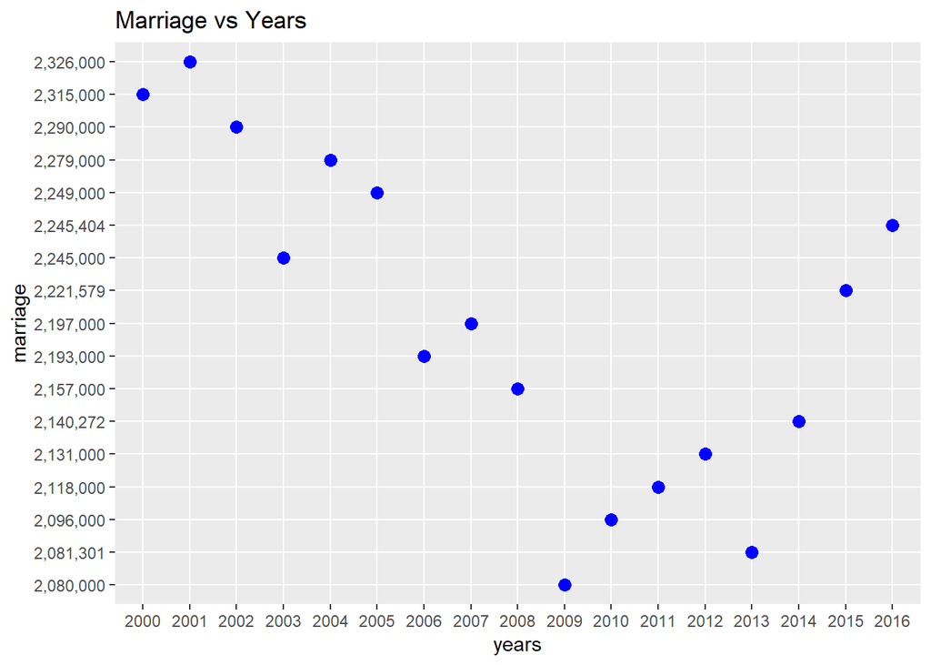

```r
qplot(data=md_ds_new, x=years, y=marriage, size=I(3), color=I("Blue"), main="Marriage vs Years")
```

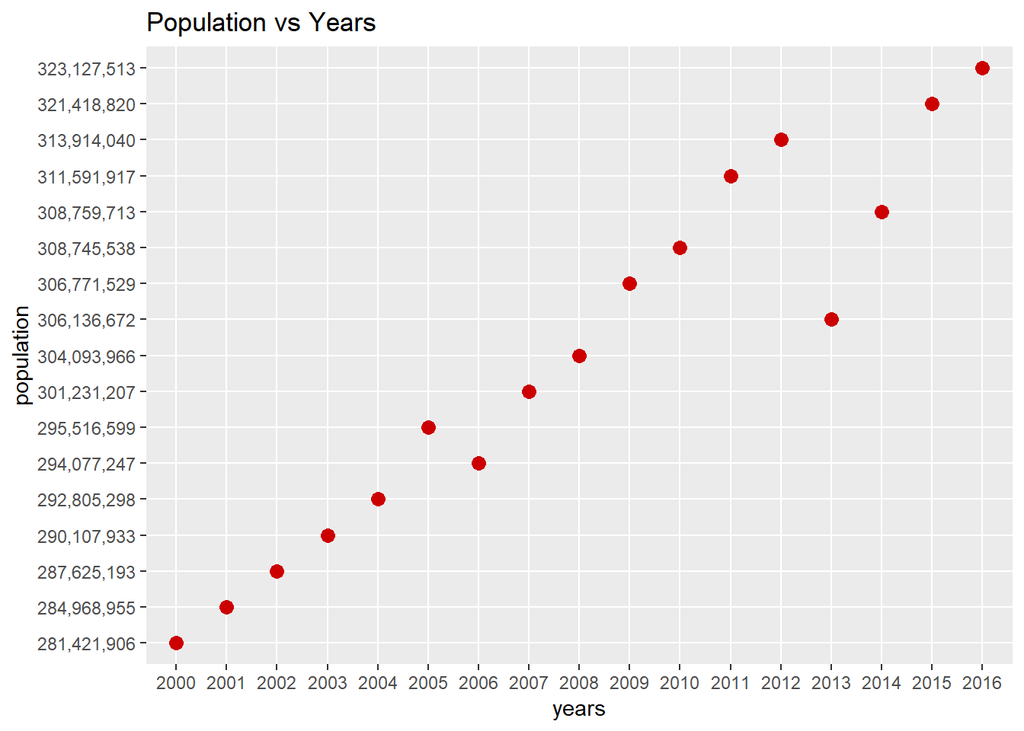

```r
qplot(data=md_ds_new, x=years, y=population, size=I(3), color=I("#CC0000"), main="Population vs Years")
```

### DATASET 3: IT Revenue

```r
library(sqldf)

it_revenue_ds <-sqldf(c("Drop table if exists revenue","CREATE table IT_revenue ( ID serial PRIMARY KEY, Year int (10) NOT NULL, Google int NULL, Facebook int NULL, Yahoo int NULL, Microsoft int NULL, AOL int NULL)",
  "INSERT INTO IT_revenue (ID, Year, Google, Facebook, Yahoo, Microsoft, AOL) Values ('1','2009','0.36','0.56', '1.26', '0.37', '0.51'), ('2', '2010','0.86','1.21', '1.43', '0.51', '0.47'), ('3', '2011', '1.67', '1.73', '1.36', '0.6', '0.53'), ('4','2012','2.26','2.18', '1.35','0.9','0.7'), ('5','2013','2.99','3.17','1.27','0.79','0.73')", "Select Year, Google, Facebook, Yahoo, Microsoft, AOL from IT_revenue"))

#Original data
datatable(it_revenue_ds)
```

|  | Year | Google | Facebook | Yahoo | Microsoft | AOL |
| --- | --- | --- | --- | --- | --- | --- |
| 1 | 2009 | 0.36 | 0.56 | 1.26 | 0.37 | 0.51 |
| 2 | 2010 | 0.86 | 1.21 | 1.43 | 0.51 | 0.47 |
| 3 | 2011 | 1.67 | 1.73 | 1.36 | 0.6 | 0.53 |
| 4 | 2012 | 2.26 | 2.18 | 1.35 | 0.9 | 0.7 |
| 5 | 2013 | 2.99 | 3.17 | 1.27 | 0.79 | 0.73 |

```r
it_revenue_ds1 <- gather(it_revenue_ds,"Company","Revenue",2:6)

#Gathered data
datatable(it_revenue_ds1)
```

|  | Year | Company | Revenue |
| --- | --- | --- | --- |
| 1 | 2009 | Google | 0.36 |
| 2 | 2010 | Google | 0.86 |
| 3 | 2011 | Google | 1.67 |
| 4 | 2012 | Google | 2.26 |
| 5 | 2013 | Google | 2.99 |
| 6 | 2009 | Facebook | 0.56 |
| 7 | 2010 | Facebook | 1.21 |
| 8 | 2011 | Facebook | 1.73 |
| 9 | 2012 | Facebook | 2.18 |
| 10 | 2013 | Facebook | 3.17 |

[output cut: 15 more lines]

```r
it_revenue_ds1_grp1 <- it_revenue_ds1 %>%
  group_by(Company) %>%
  summarize(total_revenue=sum(Revenue, na.rm=TRUE), count=n(), avg_revenue=mean(Revenue,na.rm=TRUE))

it_revenue_ds1_grp1
```

```
## # A tibble: 5 x 4
##   Company   total_revenue count avg_revenue
##   <chr>             <dbl> <int>       <dbl>
## 1 AOL                2.94     5       0.588
## 2 Facebook           8.85     5       1.77
## 3 Google             8.14     5       1.63
## 4 Microsoft          3.17     5       0.634
## 5 Yahoo              6.67     5       1.33
```

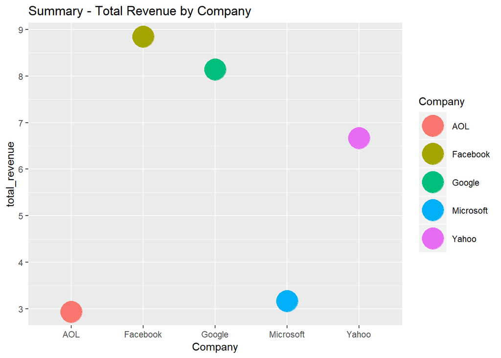

```r
qplot(data=it_revenue_ds1_grp1, x=Company, y=total_revenue, color=Company, size=I(10), main="Summary - Total Revenue by Company")
```

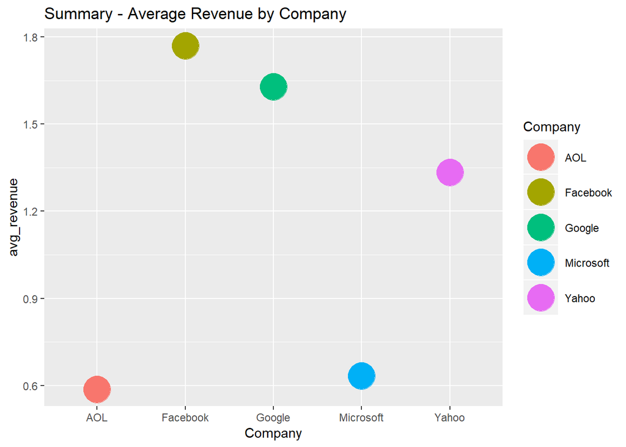

```r
qplot(data=it_revenue_ds1_grp1, x=Company, y=avg_revenue, color=Company, size=I(10), main="Summary - Average Revenue by Company")
```

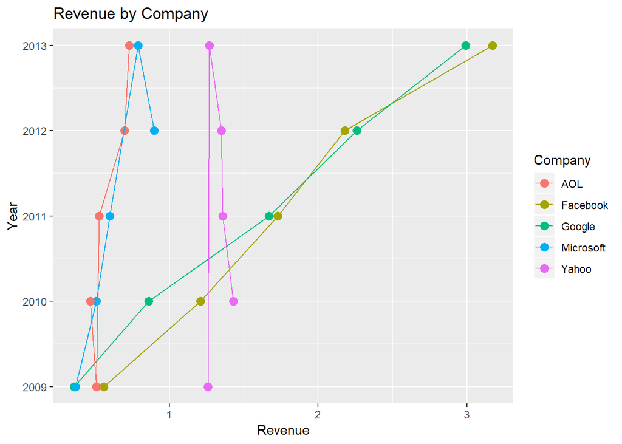

```r
qplot(data=it_revenue_ds1, x=Revenue, y=Year, color=Company, size=I(3), main="Revenue by Company") + geom_line()
```

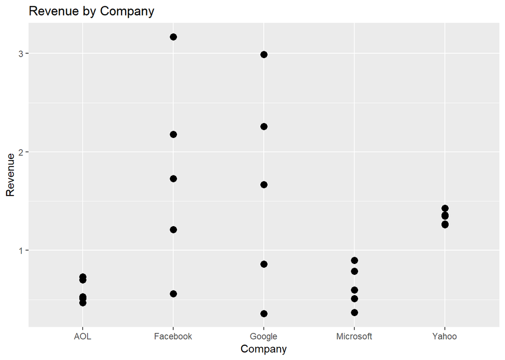

```r
qplot(data=it_revenue_ds1, x=Company, y=Revenue, size=I(3), main="Revenue by Company")
```

### Conclusion

#### We examined the revenue of various companies and from the data it is evident that there are two companies that uses freemium model that took off. Both Facebook and Google offer their services free but their revenue grew more than companies that used paid subscription model. So as they say free is not really free!!! They are a way to attract more paid customers by upselling other products.